# Extracting Stock Data Using a Python Library

A company's stock share is a piece of the company more precisely:

**A stock (also known as equity) is a security that represents the ownership of a fraction of a corporation. This entitles the owner of the stock to a proportion of the corporation's assets and profits equal to how much stock they own. Units of stock are called "shares." [1]**

An investor can buy a stock and sell it later. If the stock price increases, the investor profits, If it decreases,the investor with incur a loss. Determining the stock price is complex; it depends on the number of outstanding shares, the size of the company's future profits, and much more. People trade stocks throughout the day the stock ticker is a report of the price of a certain stock, updated continuously throughout the trading session by the various stock market exchanges.

You are a data scientist working for a hedge fund; it's your job to determine any suspicious stock activity. In this lab you will extract stock data using a Python library. We will use the yfinance library, it allows us to extract data for stocks returning data in a pandas dataframe. You will use the lab to extract.

## Table of Contents

- Using yfinance to Extract Stock Info
- Using yfinance to Extract Historical Share Price Data
- Using yfinance to Extract Historical Dividends Data
- Exercise

Estimated Time Needed: **30 min**

```python
!pip install yfinance==0.1.67
#!pip install pandas==1.3.3
```

```python
import yfinance as yf
import pandas as pd
```

## Using the yfinance Library to Extract Stock Data

Using the `Ticker` module we can create an object that will allow us to access functions to extract data. To do this we need to provide the ticker symbol for the stock, here the company is Apple and the ticker symbol is `AAPL`.

```python
apple = yf.Ticker("AAPL")
```

Now we can access functions and variables to extract the type of data we need. You can view them and what they represent here https://aroussi.com/post/python-yahoo-finance.

### Stock Info

Using the attribute `info` we can extract information about the stock as a Python dictionary.

```python
apple_info=apple.info
```

We can get the `'country'` using the key country

```python
apple_info['country']
```

```
'United States'
```

### Extracting Share Price

A share is the single smallest part of a company's stock that you can buy, the prices of these shares fluctuate over time. Using the `history()` method we can get the share price of the stock over a certain period of time. Using the `period` parameter we can set how far back from the present to get data. The options for `period` are 1 day (1d), 5d, 1 month (1mo) , 3mo, 6mo, 1 year (1y), 2y, 5y, 10y, ytd, and max.

```python
apple_share_price_data = apple.history(period="max")
```

The format that the data is returned in is a Pandas DataFrame. With the `Date` as the index the share `Open`, `High`, `Low`, `Close`, `Volume`, and `Stock Splits` are given for each day.

```python
apple_share_price_data.head()
```

| Date | Open | High | Low | Close | Volume | Dividends | Stock Splits |
| --- | --- | --- | --- | --- | --- | --- | --- |
| 1980-12-12 | 0.100039 | 0.100474 | 0.100039 | 0.100039 | 469033600 | 0.0 | 0.0 |
| 1980-12-15 | 0.095255 | 0.095255 | 0.094820 | 0.094820 | 175884800 | 0.0 | 0.0 |
| 1980-12-16 | 0.088296 | 0.088296 | 0.087861 | 0.087861 | 105728000 | 0.0 | 0.0 |
| 1980-12-17 | 0.090035 | 0.090470 | 0.090035 | 0.090035 | 86441600 | 0.0 | 0.0 |
| 1980-12-18 | 0.092646 | 0.093081 | 0.092646 | 0.092646 | 73449600 | 0.0 | 0.0 |

We can reset the index of the DataFrame with the `reset_index` function. We also set the `inplace` paramter to `True` so the change takes place to the DataFrame itself.

```python
apple_share_price_data.reset_index(inplace=True)
```

We can plot the `Open` price against the `Date`:

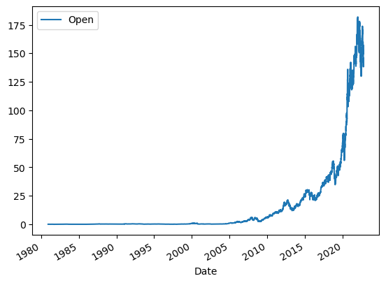

```python
apple_share_price_data.plot(x="Date", y="Open")
```

### Extracting Dividends

Dividends are the distribution of a companys profits to shareholders. In this case they are defined as an amount of money returned per share an investor owns. Using the variable `dividends` we can get a dataframe of the data. The period of the data is given by the period defined in the 'history` function.

```python
apple.dividends
```

```
Date
1987-05-11    0.000536
1987-08-10    0.000536
1987-11-17    0.000714
1988-02-12    0.000714
1988-05-16    0.000714
                ...
2021-08-06    0.220000
2021-11-05    0.220000
2022-02-04    0.220000
2022-05-06    0.230000
2022-08-05    0.230000
Name: Dividends, Length: 76, dtype: float64
```

We can plot the dividends overtime:

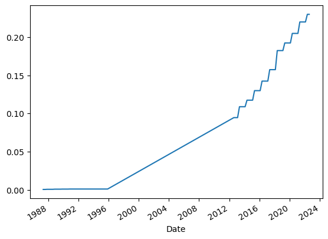

```python
apple.dividends.plot()
```

## Exercise

Now using the `Ticker` module create an object for AMD (Advanced Micro Devices) with the ticker symbol is `AMD` called; name the object `amd`.

```python
amd = yf.Ticker("AMD")
```

**Question 1** Use the key `'country'` to find the country the stock belongs to, remember it as it will be a quiz question.

```python
amd_info=amd.info
amd_info['country']
```

```
'United States'
```

**Question 2** Use the key `'sector'` to find the sector the stock belongs to, remember it as it will be a quiz question.

```python
amd_info['sector']
```

```
'Technology'
```

**Question 3** Obtain stock data for AMD using the `history` function, set the `period` to max. Find the `Volume` traded on the first day (first row).

```python
amd_share_price_data = amd.history(priod="max")
amd_share_price_data.head()
```

| Date | Open | High | Low | Close | Volume | Dividends | Stock Splits |
| --- | --- | --- | --- | --- | --- | --- | --- |
| 2022-09-08 | 80.029999 | 83.449997 | 79.239998 | 82.779999 | 89089300 | 0 | 0 |
| 2022-09-09 | 84.029999 | 85.680000 | 83.839996 | 85.449997 | 68907700 | 0 | 0 |
| 2022-09-12 | 84.889999 | 85.349998 | 83.459999 | 84.639999 | 71922500 | 0 | 0 |
| 2022-09-13 | 80.959999 | 81.470001 | 76.800003 | 77.029999 | 80921200 | 0 | 0 |
| 2022-09-14 | 77.099998 | 78.080002 | 75.870003 | 77.449997 | 71483000 | 0 | 0 |

## About the Authors:

Joseph Santarcangelo has a PhD in Electrical Engineering, his research focused on using machine learning, signal processing, and computer vision to determine how videos impact human cognition. Joseph has been working for IBM since he completed his PhD.

Azim Hirjani

## Change Log

[output not shown]